# Daily Show Versus Saturday Night Live

## A Comparison of Star Quality

### By Nick Rose

Does the daily Show or Saturday Night Live produce more high quality actors? Is it better for your career to be on one show or the other? To answer these questions, I pulled a cast list of SNL actors and Daily Show from Wikipedia which produced a total of 183 Actors, 141 on SNL and 46 on the Daily Show. Four Actors (A. Whitney Brown, Michael Che, Rob Riggle, and Nancy Walls) appeared on both shows.

I used IMDB to download every movie and TV Show associated with each actor. There were 8358 unique movies and 2460 unique TV Shows between them all, though some of these are movies and TV shows that are in production or not yet released.

I then used Rotten Tomatoes to download the Audience Score for every movie and TV Show (except those that had SNL, Saturdayl Night Live or Daily Show in the title). This led to a list of 5863 movies and TV shows between 183.

We used this data to calcualte the mean for each actor. To determine if the length of time an actor spends on the show helps their career, we made a scatterplot of the data

[interactive chart not shown]

Interestingly, the highest three points (all above 75) are Emily Prager (for the show Hawk), Vance DeGeneres (due to his work on the Ellen Show), and Bob Wiltfong. Unfortunately the point way at the bottom, it’s the new Daily Show host Trevor Noah and represents the appearance as himself on the show “Would I Lie to You?”. The points far out to the right on the graph that’s Jon Stewart (17 years) and Lewis Black (21) who is part of the current season. Statistical Analysis (and visual observation) suggests that the number of years on the show doesn’t effect your Rotten Tomatoes score.

We can also see that the shows consistently produce talent of equal caliber. Thus if given an opportunity to be on the Daily Show or SNL the outcome for your career will be the same.

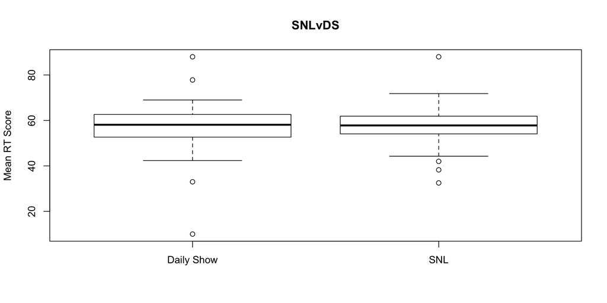

I also looked at each show to see if there were years when they were lacking in star power. As you can see from the figures below, both shows consistently had quality stars for every year they’ve been on the air. Overall: A pretty solid tie between the two shows

[interactive chart not shown]